# Labour Market Conditions and Further Education in the US since 2000

Group 37 – Introduction to Programming

Authors

Allotey Kelvin, Lloyd

Braun, Finn

Bruehwiler, Nils

Troillet, Cyril

Published

May 20, 2026

## Research question

Do young Americans pursue further education in response to deteriorating labour market conditions in the US since 2000?

The intuition is simple. The opportunity cost of going back to school is the wage you would otherwise earn. When the labour market is weak, graduates have a more difficult time finding an entry-level job that suits their preferences. A weak labour market is often characterised by a high unemployment rate and/or low wage offers, among other factors. This circumstance leads many students to pursue further education in hopes of better times (staying in school longer has relatively lower opportunity costs). We test this hypothesis using master’s enrolment, the most common form of further education for students who already hold a bachelor’s degree.

## Data

Our database holds nine series for the US since 2000:

The data lives in a DuckDB star schema (see Figure 1) built once by `data/build_fred.py`. After the build, the database is the only data source for this brief, every figure and table comes from `LabourMarketFramework` in `src/labour_market_framework.py`.

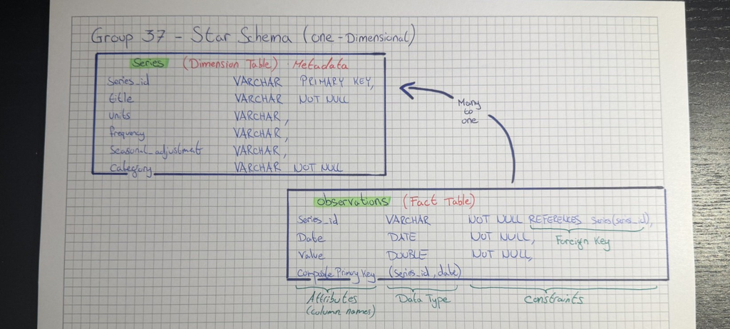

Figure 1: Database schema. One dimension table (`series`) holds the metadata, one fact table (`observations`) holds the values. `observations.series_id` references `series.series_id`, with `(series_id, date)` as the composite primary key on the fact table.

## A first look at the data

Table 1 summarises every series.

Table 1: Summary statistics for the nine series, full sample. Master’s enrollment is annual (23 observations, 2000-2022), the others are monthly.

|  | count | mean | std | min | max |
| --- | --- | --- | --- | --- | --- |
| JTSHIL | 304.0 | 5189.10 | 681.40 | 3639.0 | 8133.0 |
| JTSJOR | 304.0 | 3.67 | 1.26 | 1.7 | 7.5 |
| JTSQUR | 304.0 | 2.01 | 0.36 | 1.2 | 3.0 |
| LNS12032194 | 315.0 | 5569.16 | 1782.79 | 3144.0 | 10880.0 |
| LNS14027662 | 315.0 | 2.87 | 1.02 | 1.5 | 8.4 |
| MASTERS_ENROLLMENT | 23.0 | 2788406.00 | 306684.73 | 2156896.0 | 3211199.0 |
| PAYEMS | 316.0 | 140653.77 | 9268.02 | 129706.0 | 158736.0 |
| UNRATE | 315.0 | 5.63 | 1.94 | 3.4 | 14.8 |
| USREC | 316.0 | 0.09 | 0.28 | 0.0 | 1.0 |

## The labour market since 2000

Figure 2 plots job openings against unemployment, the Beveridge curve. A healthy market shows a downward slope: when unemployment falls, vacancies rise, and the points sit on one curve. Outward shifts indicate structural change.

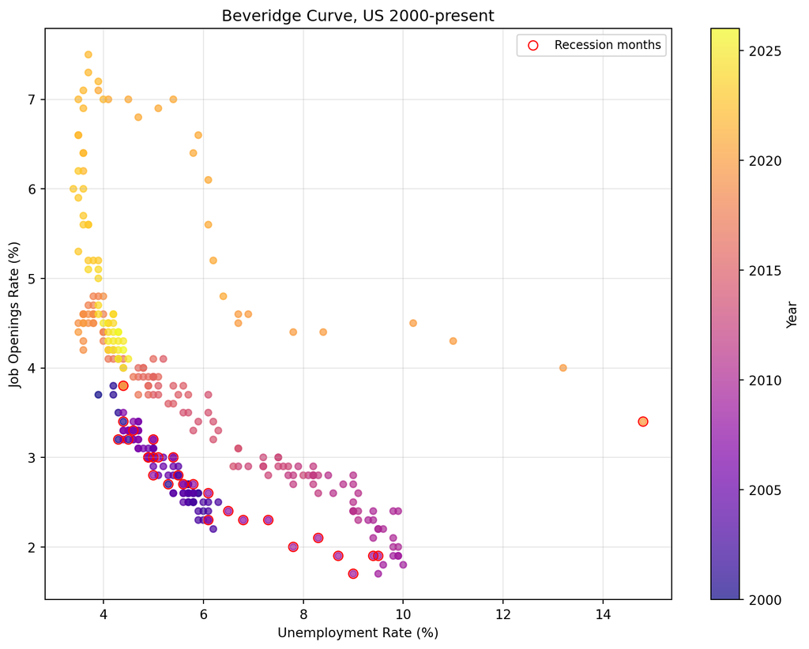

Figure 2: US Beveridge curve, December 2000 to present. Points coloured by year; recession months ringed in red.

## A composite stress index

UNRATE captures one dimension of the labour market. To test our research question we want a broader approach, so we built our own **labour-market stress index** using the `compute_stress_index` method on our class.

**Goal.** Summarise the labour-market state in a single, comparable series so we can ask whether enrollment responds to the labour market measured as our index, rather than to one indicator like UNRATE alone.

**Reading the index.** Zero is roughly average for 2000-present. Positive readings mean conditions are worse than average, negative readings mean better.

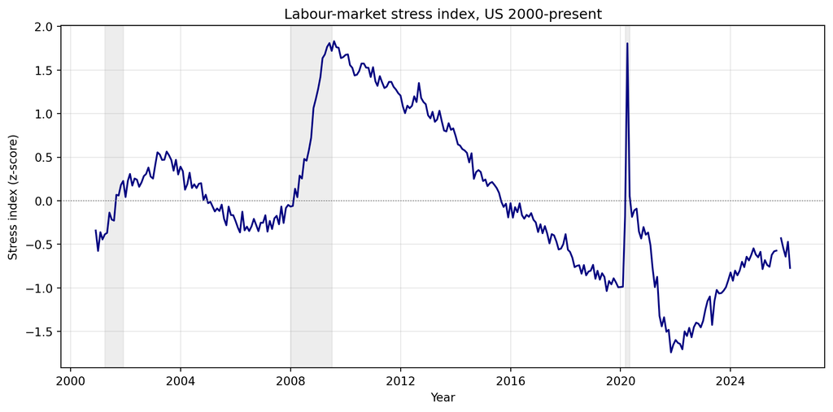

Figure 3: Labour-market stress index, US December 2000 to present. Z-scored, higher means worse conditions. Recessions shaded.

The index lines up with the three recessions of our sample. It rises through the 2001 dot-com bust, peaks at the 2008-09 financial crisis, and spikes sharply in April 2020 before falling back again. Since 2022 a labour market is observed that, under historical comparison, is quite tight.

## Enrollment and the stress index

Figure 4 puts the index next to the yearly growth of master’s enrollment. The left axis is the index (higher = worse), the right axis is enrollment growth.

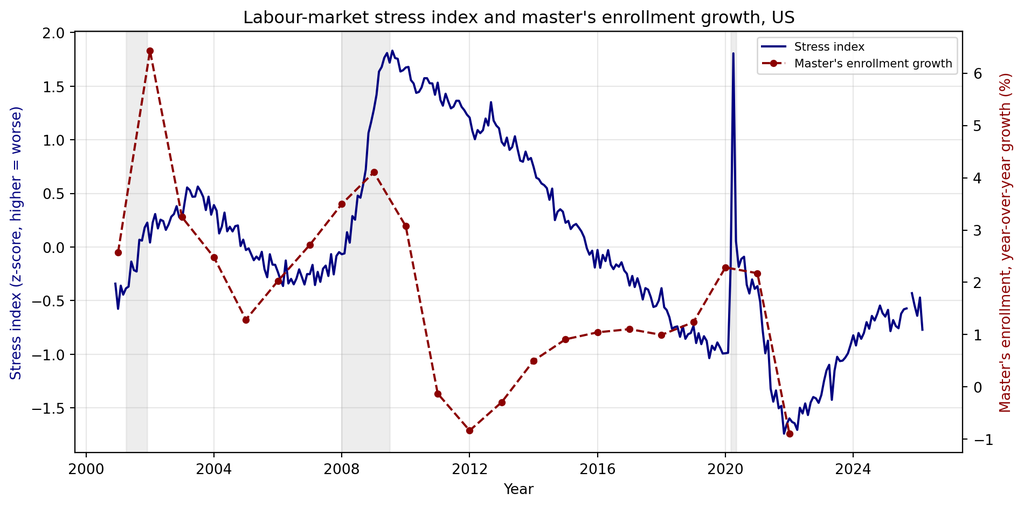

Figure 4: Labour-market stress index (left axis, blue) and master’s enrollment growth (right axis, red). Recessions shaded.

The 2001 and 2008-09 recessions match our intuition closely. The index rises strongly during each recession, enrollment growth peaks roughly one year later, at 6.5% in 2002 and 4.1% in 2009. The one-year lag is explained by the length of the academic admission cycle: people who decide to go back to school during a downturn show up in enrollment data the next September.

## Discussion

**The opportunity-cost intuition holds, with a 2020 exception.** For the 2001 and 2008-09 recessions, master’s enrollment grew most when the broader labour-market was worst (Figure 4). The 2020 recession shows different results, that can be explained by e.g. closed campuses and disrupted admissions.

**Limitations of our analysis.** Master’s enrollment is annual and is stored at January-1 of each year, while the FRED series are monthly. We align the two using yearly growth, but the underlying admission decisions happen already earlier, not on the first of January. Also, master’s enrollment is measured in absolute figures, therefore, one has to take into account a growing US population (about 18% between 2000 and 2022) that partially explains growing master’s enrollment numbers as well. The NCES Digest has no 2023 figure yet, so the most recent enrollment observation is fall 2022. The involuntary-part-time series (`LNS12032194`) has one missing month at the very end of the sample, visible as a slightly shorter `count` in Table 1.